# Introduction to R: Practical 2

We continue from yesterday by exploring the relationship between variables, both with visualisations and statistical tests. Don’t forget to turn your knitted R markdown documents into Brightspace.

## 2.01 | Introduction to `ggplot2`

First, we must load in the dataset again, keeping only complete cases.

```r
load('./data/data_fhs.Rdata')
fhs <- fhs[complete.cases(fhs), ]
```

We should also load in the `tidyverse` package.

```r
library(tidyverse)
```

The package `ggplot2` is commonly used to produce visualisations of data.

The `ggplot()` function alone just initializes a blank plot. You can specify your x and y axis using `aes()`, but no lines or points will be drawn. You can pipe your data to `ggplot()` using `%>%` or specify it as the first argument.

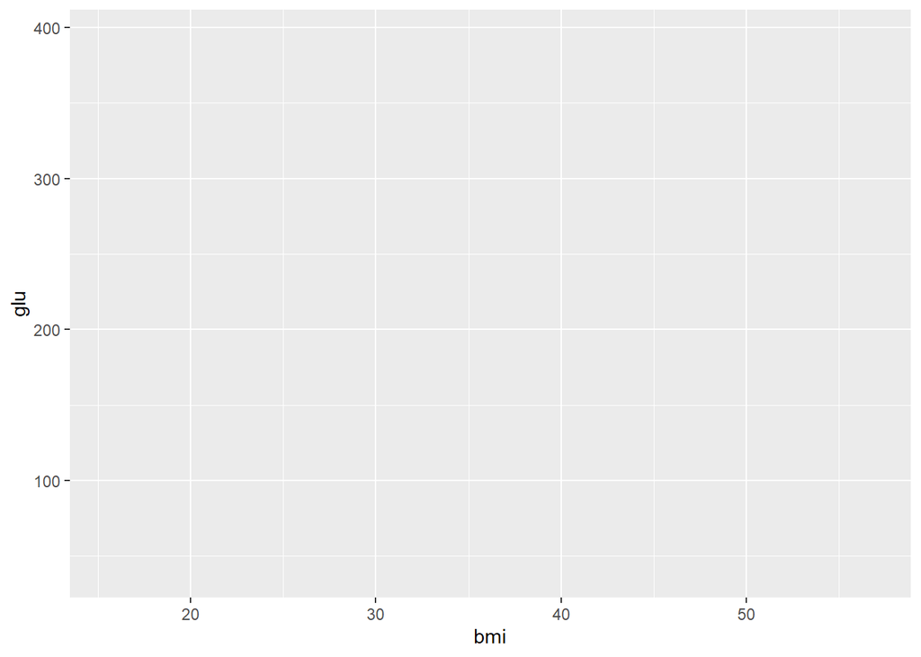

```r
fhs %>%
  ggplot(aes(bmi, glu))
```

Titles can be specified by adding `ggtitle()` to the `ggplot()` function with the `+` operator. X and Y axis labels can also be implemented with `xlab()` and `ylab()`, respectively.

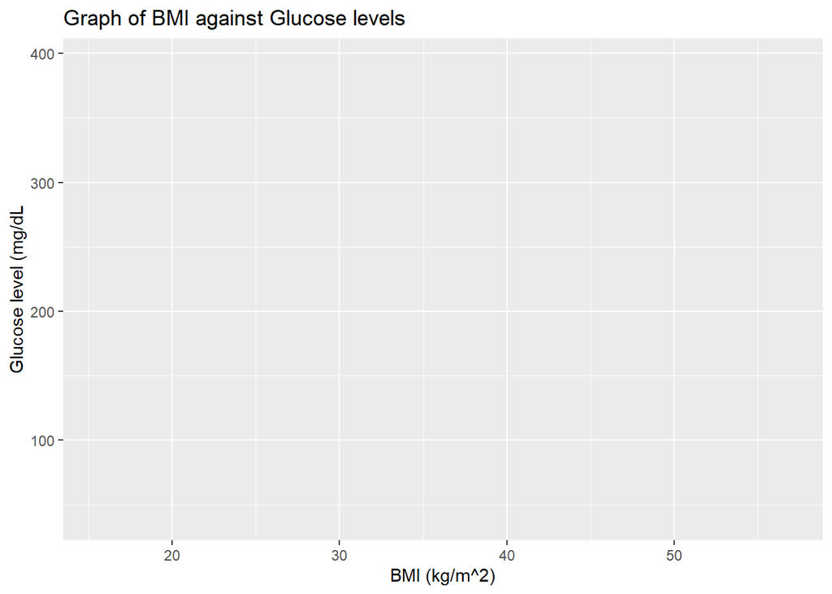

```r
fhs %>%
  ggplot(aes(bmi, glu)) +
  ggtitle("Graph of BMI against Glucose levels") +
  xlab("BMI (kg/m^2)") +
  ylab("Glucose level (mg/dL")
```

In order to add data visualisation to our graph, we need to add `geom` elements. One of these, `geom_bar()` is used to create bar charts for categorical variables.

The `aes()` function can be moved inside the `geom_bar()`, which is useful if you want to overlap multiple `geom` elements showcasing different aspects of your data.

Additionally, `alpha`, `colour`, and `fill` options can specify the appearance of the bars. Note, you can spell colour either the American or English way - both are accepted as arguments. Changing these options can be done for other `geom` elements as well.

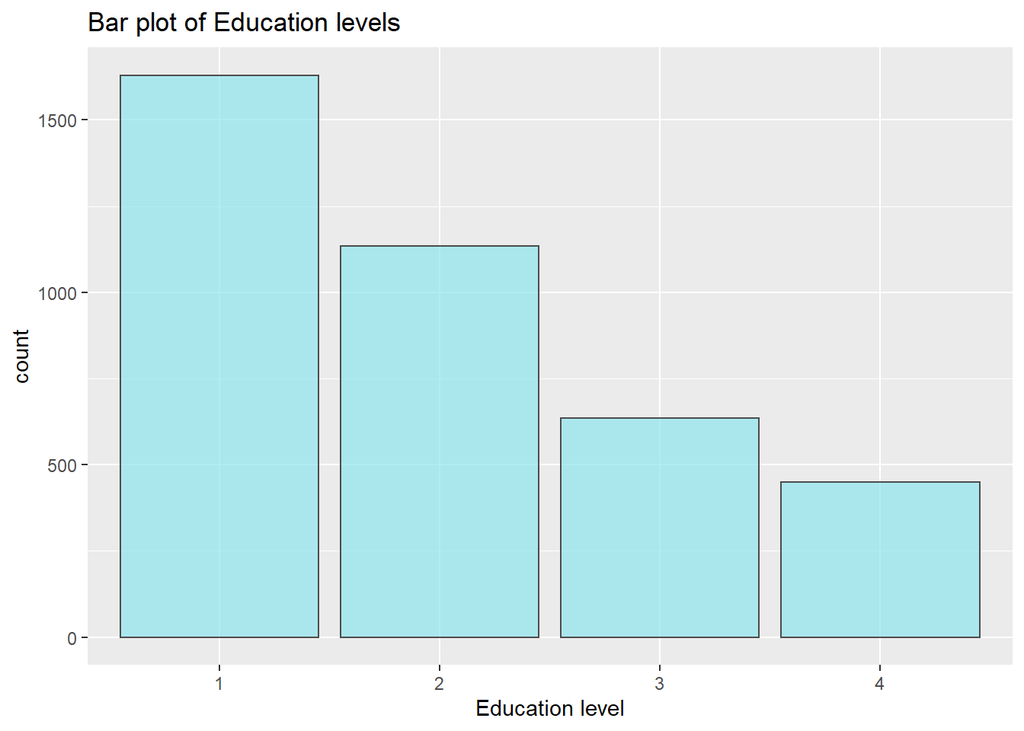

```r
fhs %>%
  ggplot() +
  geom_bar(aes(edu), alpha=0.7, colour='grey30', fill='cadetblue2') +
  ggtitle("Bar plot of Education levels") +
  xlab("Education level")
```

Bars can be coloured by other variables to see the distribution of one category within another. This is done by moving the `fill` option inside the `aes()` function and specifying a categorical variable.

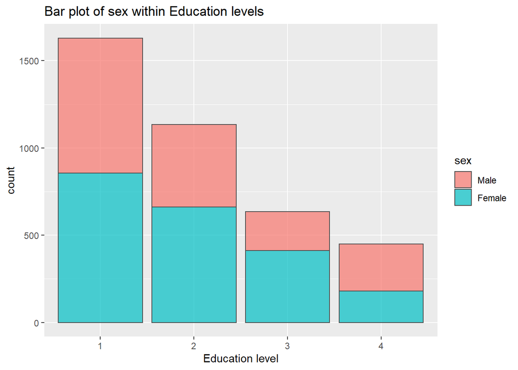

```r
fhs %>%
  ggplot() +
  geom_bar(aes(edu, fill=sex), alpha=0.7, colour='grey30') +
  ggtitle("Bar plot of sex within Education levels") +
  xlab("Education level")
```

Subsetting, as shown yesterday with `dplyr` can also be piped into `ggplot()`. We can show the above graph only for those who experienced MI, for example.

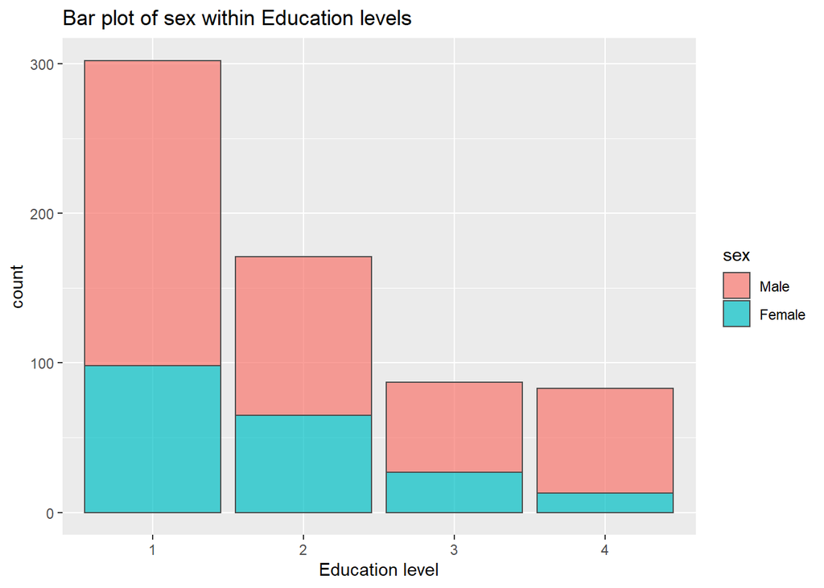

```r
fhs %>%
  filter(mi == 'Yes') %>%
  ggplot() +
  geom_bar(aes(edu, fill=sex), alpha=0.7, colour='grey30') +
  ggtitle("Bar plot of sex within Education levels") +
  xlab("Education level")
```

To view bars side-by-side instead of stacked, set `position` to `dodge`.

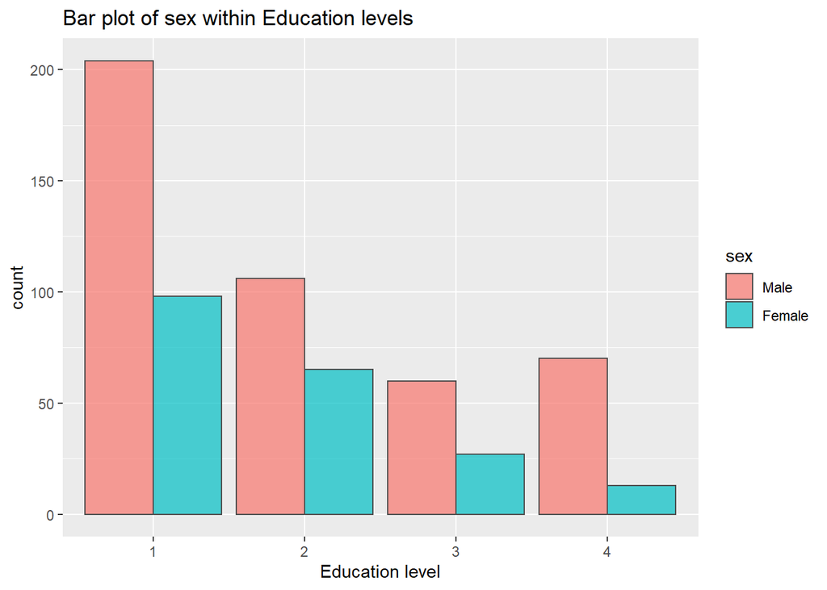

```r
fhs %>%
  filter(mi == 'Yes') %>%
  ggplot() +
  geom_bar(aes(edu, fill=sex), alpha=0.7, colour='grey30', position="dodge") +
  ggtitle("Bar plot of sex within Education levels") +
  xlab("Education level")
```

For continuous variables, we divide the x axis into bins and visualize using `geom_histogram()`.

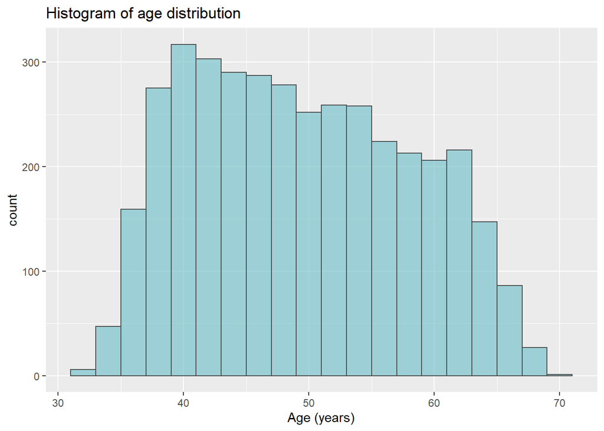

```r
fhs %>%
  ggplot() +
  geom_histogram(aes(age), binwidth=2, alpha=0.7, colour='grey30', fill='cadetblue3') +
  ggtitle("Histogram of age distribution") +
  xlab("Age (years)")
```

To show the distribution of a continuous variable within categories, you can use `facet_wrap()` which takes a `formula` class as an argument. Separating plots by group using `facet_wrap()` is possible for most `ggplot` graphics.

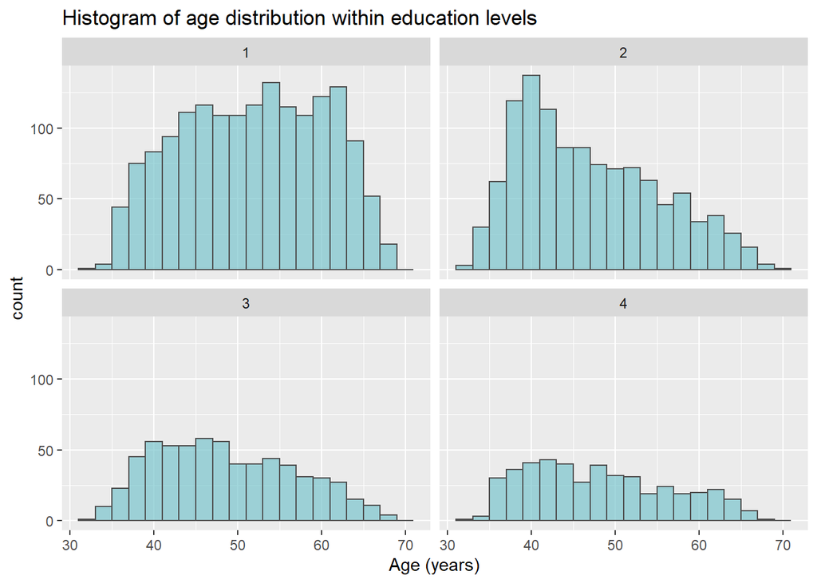

```r
fhs %>%
  ggplot() +
  geom_histogram(aes(age), binwidth=2, alpha=0.7, colour='grey30', fill='cadetblue3') +
  facet_wrap(~edu) +
  ggtitle("Histogram of age distribution within education levels") +
  xlab("Age (years)")
```

In order to show a smoothed version of a histogram, a density plot, we use `geom_density`.

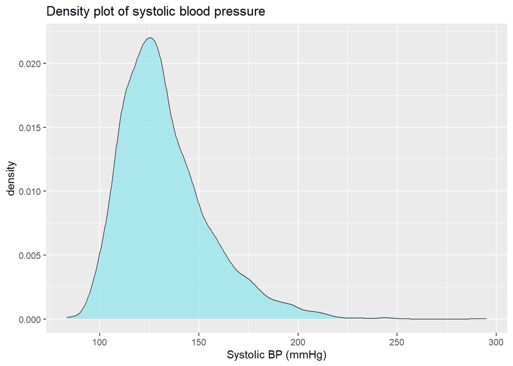

```r
fhs %>%
  ggplot() +
  geom_density(aes(sys_bp), alpha=0.7, colour='grey30', fill='cadetblue2') +
  ggtitle("Density plot of systolic blood pressure") +
  xlab("Systolic BP (mmHg)")
```

If you want to look at a variable’s distribution between groups, use the `fill` option within `aes()`.

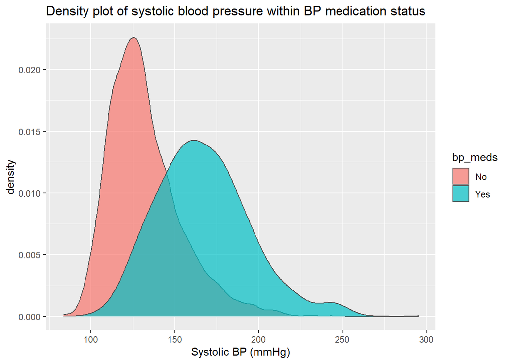

```r
fhs %>%
  ggplot() +
  geom_density(aes(sys_bp, fill=bp_meds), alpha=0.7, colour='grey30') +
  ggtitle("Density plot of systolic blood pressure within BP medication status") +
  xlab("Systolic BP (mmHg)")
```

This will show the distributions separately, but you can also stack them with a `position` argument.

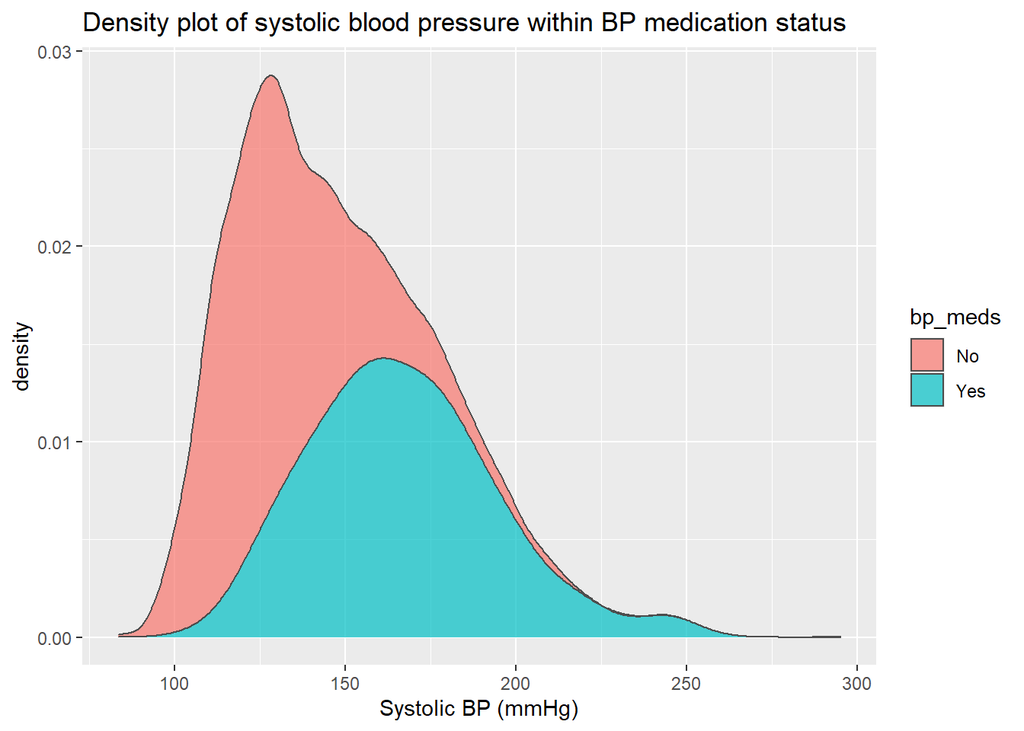

```r
fhs %>%
  ggplot() +
  geom_density(aes(sys_bp, fill=bp_meds), alpha=0.7, colour='grey30', position="stack") +
  ggtitle("Density plot of systolic blood pressure within BP medication status") +
  xlab("Systolic BP (mmHg)")
```

### Exercise F

1. A bar plot of MI, coloured by smoking status

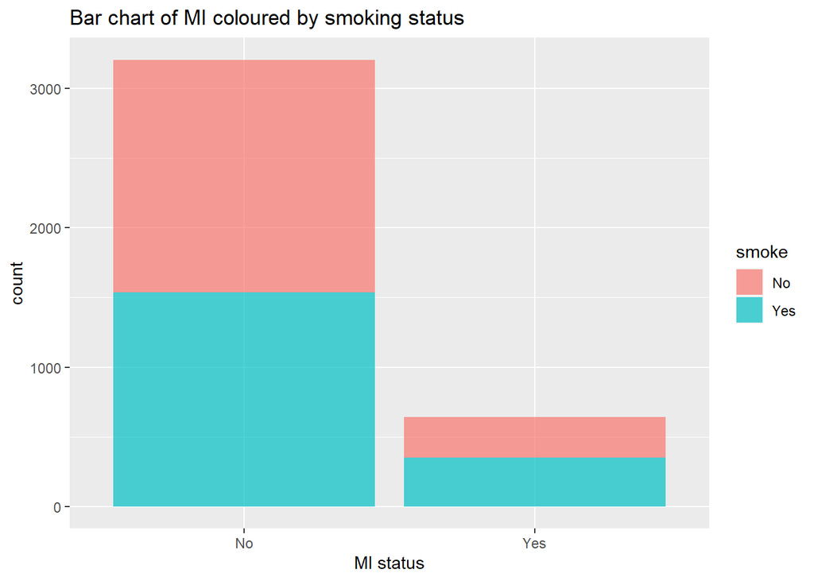

```r
fhs %>%
  ggplot() +
  geom_bar(aes(mi, fill=smoke), alpha=0.7) +
  ggtitle('Bar chart of MI coloured by smoking status') +
  xlab('MI status')
```

2. A histogram of total cholesterol in overweight individuals

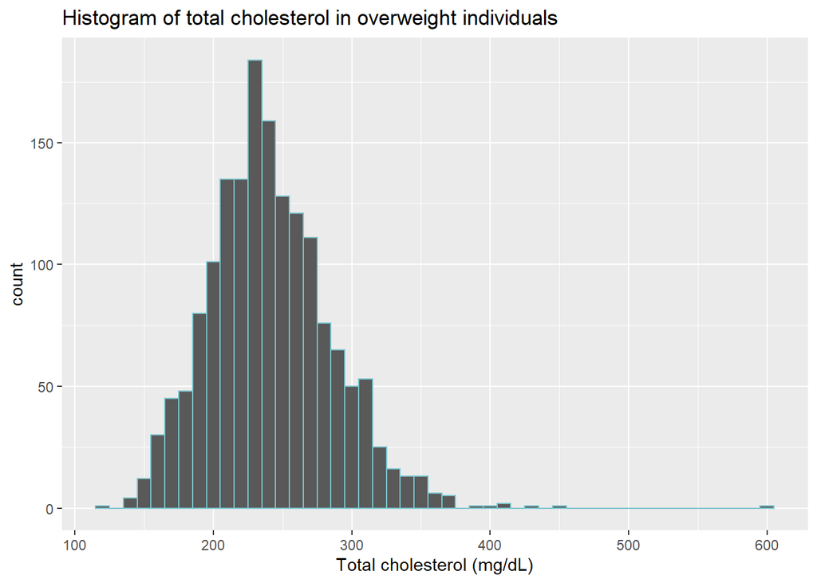

```r
fhs %>%
  filter(bmi >= 25 & bmi < 30) %>%
  ggplot() +
  geom_histogram(aes(tc), binwidth=10, colour='cadetblue3') +
  ggtitle('Histogram of total cholesterol in overweight individuals') +
  xlab('Total cholesterol (mg/dL)')
```

3. Four density plots of age for each education level

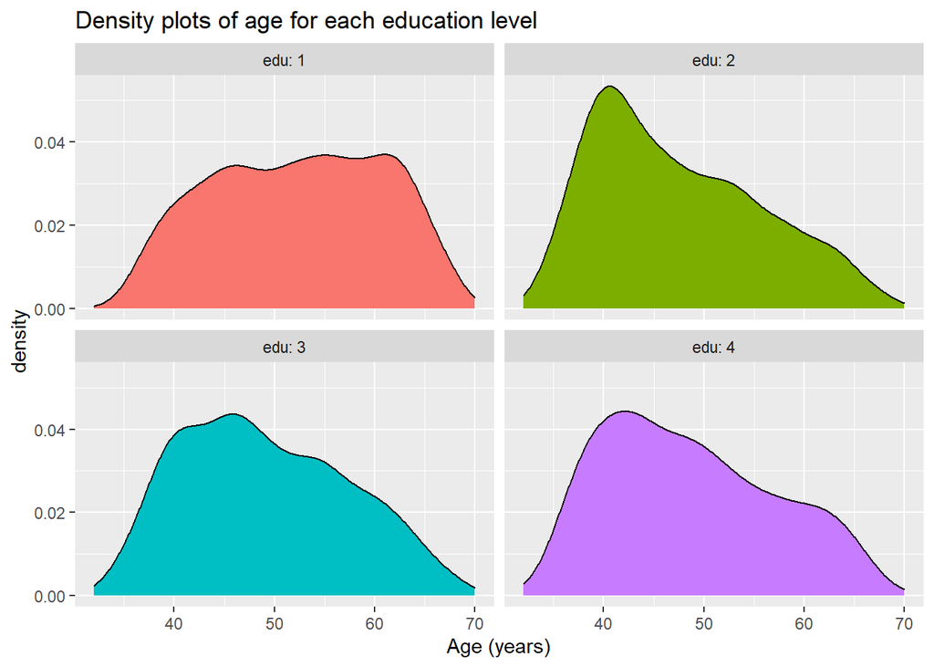

```r
fhs %>%
  ggplot() +
  geom_density(aes(age, fill=edu), show.legend=F) +
  facet_wrap(~edu, labeller=label_both) +
  ggtitle('Density plots of age for each education level') +
  xlab('Age (years)')
```

4. Two bar plots of sex in current and non-smokers for those who experienced MI

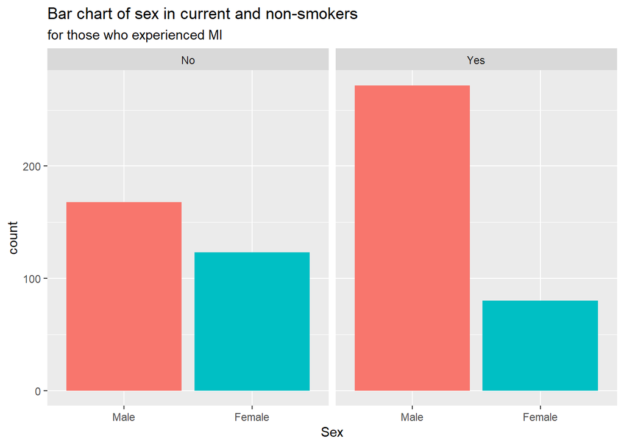

```r
fhs %>%
  filter(mi == 'Yes') %>%
  ggplot() +
  geom_bar(aes(sex, fill=sex), show.legend=F) +
  facet_wrap(~smoke) +
  ggtitle('Bar chart of sex in current and non-smokers',
          subtitle = 'for those who experienced MI') +
  xlab('Sex')
```

## 2.02 | Comparative Plots

A scatter plot can be a good way to compare two continuous variables. In `ggplot` this is implemented using `geom_point()`.

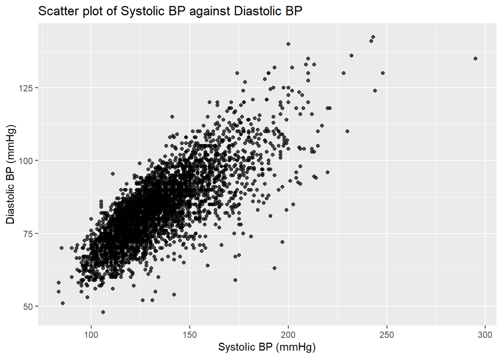

```r
fhs %>%
  ggplot() +
  geom_point(aes(sys_bp, dia_bp), alpha=0.7) +
  ggtitle("Scatter plot of Systolic BP against Diastolic BP") +
  xlab("Systolic BP (mmHg)") +
  ylab("Diastolic BP (mmHg)")
```

Reference lines can be added to plots using `geom_vline()`, `geom_hline()`, and `geom_abline()`. These are very useful for annotating plots.

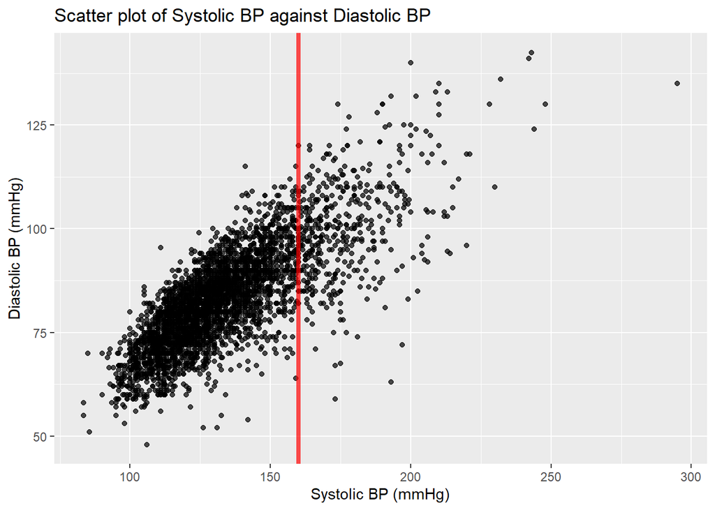

```r
fhs %>%
  ggplot() +
  geom_point(aes(sys_bp, dia_bp), alpha=0.7) +
  geom_vline(aes(xintercept=160), colour='red', size=1.5, alpha=0.7) +
  ggtitle("Scatter plot of Systolic BP against Diastolic BP") +
  xlab("Systolic BP (mmHg)") +
  ylab("Diastolic BP (mmHg)")
```

You can also use the `cut()` function alongside `seq()` to create categorical variables, to help with visualisations. `cut()` will divide its first argument by values specified in the second. The syntax of `seq()` is `start`, `end`, `interval`, so the example below specifies the vector `(30, 40, 50, 60, 70)`.

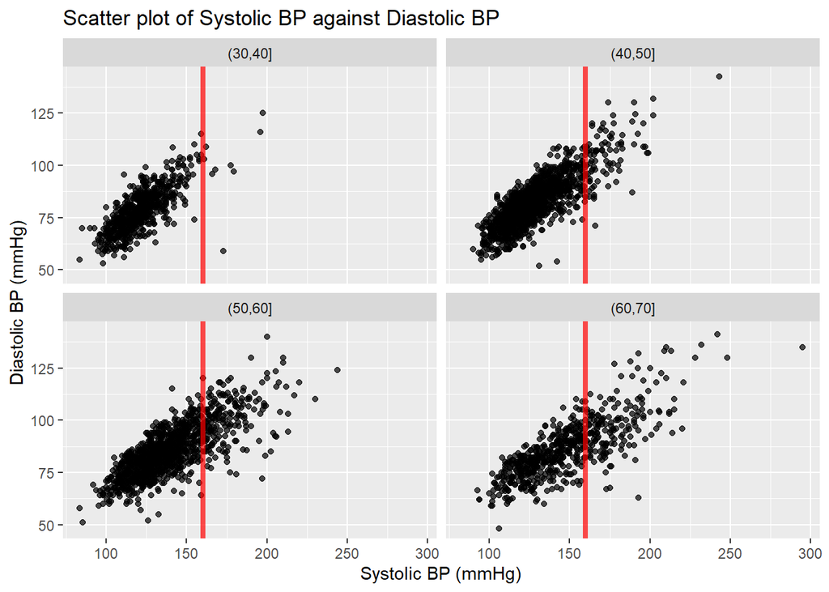

```r
fhs %>%
  ggplot() +
  geom_point(aes(sys_bp, dia_bp), alpha=0.7) +
  geom_vline(aes(xintercept=160), colour='red', size=1.5, alpha=0.7) +
  ggtitle("Scatter plot of Systolic BP against Diastolic BP") +
  xlab("Systolic BP (mmHg)") +
  ylab("Diastolic BP (mmHg)") +
  facet_wrap( ~ cut(age,seq(30,70,10)))
```

To show the distribution of a continuous variable across categories, you can use `geom_boxplot()`. This visualizes the median, upper and lower quartiles, and two whiskers, which extend to 1.5 IQRs. All outlying points are shown individually.

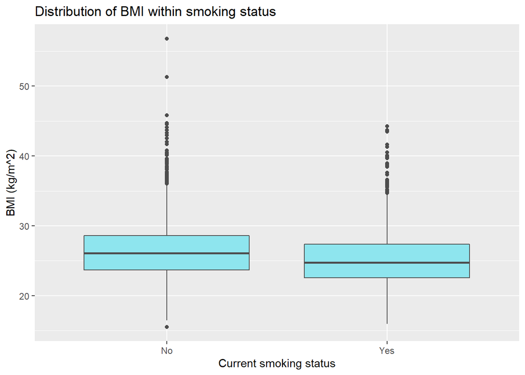

```r
fhs %>%
  ggplot() +
  geom_boxplot(aes(smoke, bmi), colour='grey30', fill='cadetblue2') +
  ggtitle("Distribution of BMI within smoking status") +
  xlab("Current smoking status") +
  ylab("BMI (kg/m^2)")
```

If you want to view a horizontal boxplot, you can use `coord_fip()`. Outliers can also be highlighted by changing their colour and shape.

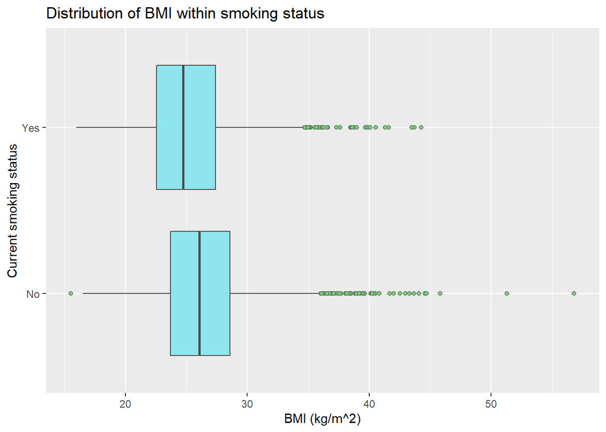

```r
fhs %>%
  ggplot() +
  geom_boxplot(aes(smoke, bmi), colour='grey30',
               fill='cadetblue2', outlier.fill='palegreen3',
               outlier.shape=21) +
  coord_flip() +
  ggtitle("Distribution of BMI within smoking status") +
  xlab("Current smoking status") +
  ylab("BMI (kg/m^2)")
```

Finally, box plots can also be split by a further category using the `fill` or `color` options within `aes()`.

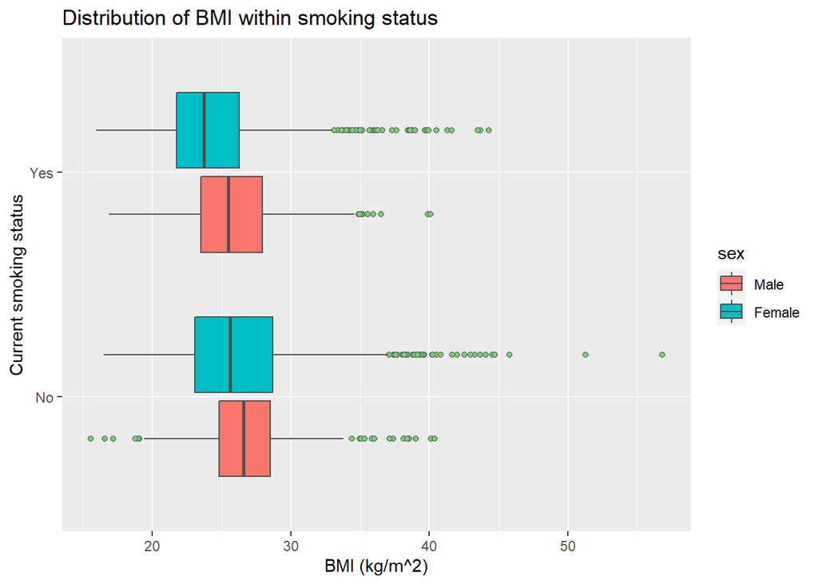

```r
fhs %>%
  ggplot() +
  geom_boxplot(aes(smoke, bmi, fill=sex), colour='grey30',
               outlier.fill='palegreen3',
               outlier.shape=21) +
  coord_flip() +
  ggtitle("Distribution of BMI within smoking status") +
  xlab("Current smoking status") +
  ylab("BMI (kg/m^2)")
```

### Exercise G

1. A scatter plot of glucose levels against BMI, coloured by diabetes status.

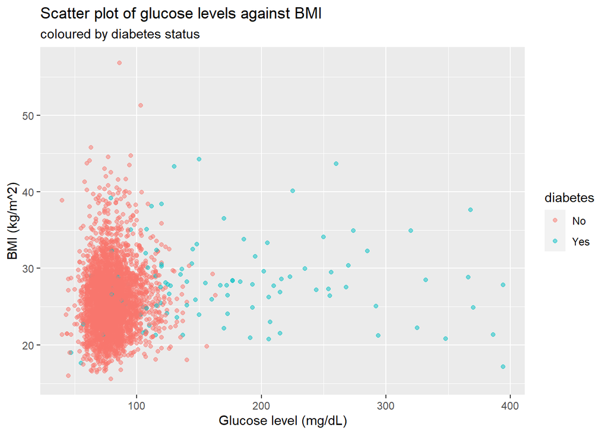

```r
fhs %>%
  ggplot() +
  geom_point(aes(glu, bmi, colour=diabetes), alpha=0.5) +
  ggtitle('Scatter plot of glucose levels against BMI',
          subtitle = 'coloured by diabetes status') +
  xlab('Glucose level (mg/dL)') +
  ylab('BMI (kg/m^2)')
```

2. A horizontal box plot of sex by systolic BP for people over the age of 60

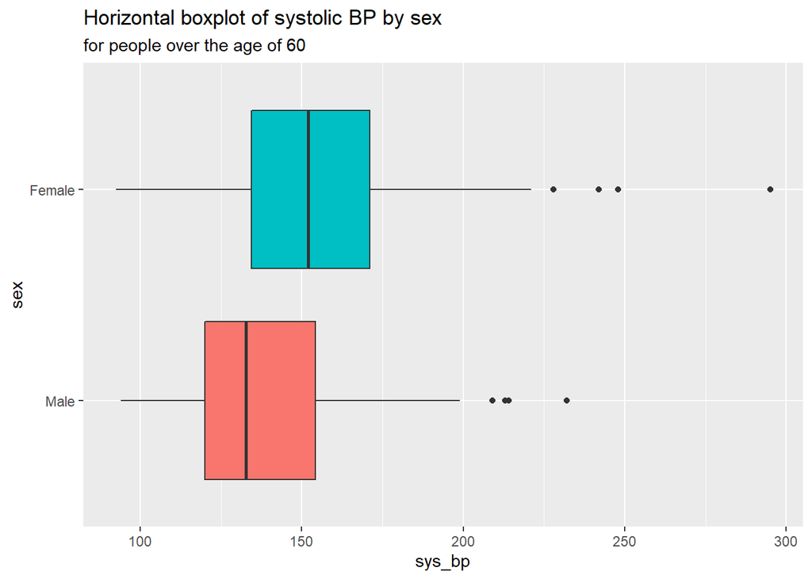

```r
fhs %>%
  filter(age > 60) %>%
  ggplot() +
  geom_boxplot(aes(sys_bp, sex, fill=sex), show.legend=F) +
  ggtitle('Horizontal boxplot of systolic BP by sex',
          subtitle='for people over the age of 60')
```

3. A scatter plot of total cholesterol against glucose for categories of BMI

```r
fhs <- fhs %>%
  mutate(
    bmi_cat = factor(cut(fhs$bmi,
                         c(0,18.5,25,30,100)),
                     labels = c('Underweight', 'Normal',
                                'Overweight', 'Obese'))
  )

xtabs(~fhs$bmi_cat)
```

```
## fhs$bmi_cat
## Underweight      Normal  Overweight       Obese
##          49        1689        1626         487
```

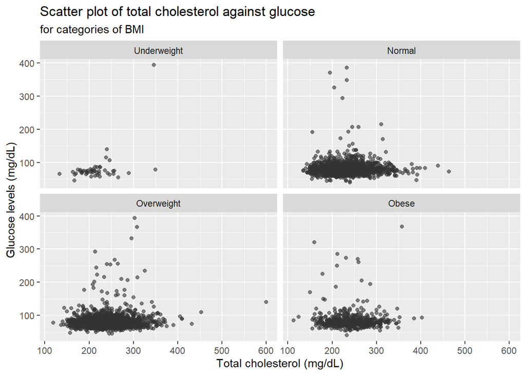

```r
fhs %>%
  ggplot() +
  geom_point(aes(tc, glu), colour='grey20', alpha=0.6) +
  facet_wrap(~bmi_cat) +
  ggtitle('Scatter plot of total cholesterol against glucose',
          subtitle = 'for categories of BMI') +
  xlab('Total cholesterol (mg/dL)') +
  ylab('Glucose levels (mg/dL)')
```

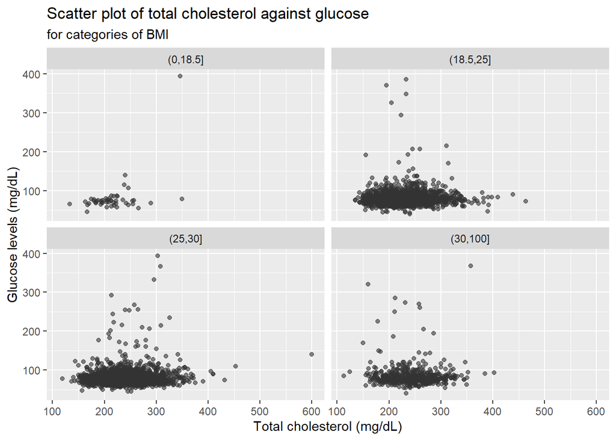

```r
fhs %>%
  ggplot() +
  geom_point(aes(tc, glu), colour='grey20', alpha=0.6) +
  facet_wrap(~cut(bmi, c(0, 18.5, 25, 30, 100))) +
  ggtitle('Scatter plot of total cholesterol against glucose',
          subtitle = 'for categories of BMI') +
  xlab('Total cholesterol (mg/dL)') +
  ylab('Glucose levels (mg/dL)')
```

## 2.03 | Statistical Tests

Next we will perform some statistical tests. Sometimes, it can be helpful to save tables so that they can be used in other functions.

```r
smoke_mi <- xtabs(~smoke+mi, fhs)
smoke_mi
```

```
##      mi
## smoke   No  Yes
##   No  1671  291
##   Yes 1537  352
```

Then, we can use this table in a chi-square test, to see if there is a significant association between smoking status and MI.

```r
chisq <- chisq.test(smoke_mi)
chisq
```

```
##
##  Pearson's Chi-squared test with Yates' continuity correction
##
## data:  smoke_mi
## X-squared = 9.7325, df = 1, p-value = 0.00181
```

In this instance, we have sufficient evidence (X2=9.73, p=0.002) that smoking and MI are significantly associated. Pearson residuals can be inspected to explore which groups are contributing most to this evidence.

```r
round(chisq$residuals, 3)
```

```
##      mi
## smoke     No    Yes
##   No   0.905 -2.022
##   Yes -0.923  2.061
```

Visualizations can often inform future statistical investigations. Perhaps, the scatter plot above suggested a positive correlation between systolic and diastolic blood pressure, but we want to investigate this further.

We can use `cor.test` to test if the correlation between two variables is significant.

```r
cor <- cor.test(~ sys_bp + dia_bp, fhs)
cor
```

```
##
##  Pearson's product-moment correlation
##
## data:  sys_bp and dia_bp
## t = 78.845, df = 3849, p-value < 2.2e-16
## alternative hypothesis: true correlation is not equal to 0
## 95 percent confidence interval:
##  0.7734942 0.7976652
## sample estimates:
##       cor
## 0.7858797
```

This shows that we have significant evidence from our data that systolic and diastolic blood pressure are strongly correlated (r=0.79, p<0.001).

```r
tt <- t.test(age ~ mi, fhs)
tt
```

```
##
##  Welch Two Sample t-test
##
## data:  age by mi
## t = -9.0315, df = 918.42, p-value < 2.2e-16
## alternative hypothesis: true difference in means between group No and group Yes is not equal to 0
## 95 percent confidence interval:
##  -4.072404 -2.618479
## sample estimates:
##  mean in group No mean in group Yes
##          49.34352          52.68896
```

This test concludes that we have sufficient evidence to suggest a significant difference in age between those who had and did not have MI (t=-9.03, p<0.001).

To run logistic regression in R, you use the `glm()` function, specifying the `family` as binomial. To explore the fit, use the `summary()` function.

```r
glmfit <- glm(mi ~ bmi + age + sex, fhs, family = "binomial")
summary(glmfit)
```

```
##
## Call:
## glm(formula = mi ~ bmi + age + sex, family = "binomial", data = fhs)
##
## Deviance Residuals:
##     Min       1Q   Median       3Q      Max
## -1.2636  -0.6548  -0.4721  -0.3237   2.4734
##
## Coefficients:
##             Estimate Std. Error z value Pr(>|z|)
## (Intercept) -4.94970    0.38682 -12.796  < 2e-16 ***
## bmi          0.05965    0.01089   5.476 4.36e-08 ***
## age          0.04537    0.00522   8.691  < 2e-16 ***
## sexFemale   -1.19593    0.09413 -12.705  < 2e-16 ***
## ---
## Signif. codes:  0 '***' 0.001 '**' 0.01 '*' 0.05 '.' 0.1 ' ' 1
##
## (Dispersion parameter for binomial family taken to be 1)
##
##     Null deviance: 3474  on 3850  degrees of freedom
## Residual deviance: 3191  on 3847  degrees of freedom
## AIC: 3199
##
## Number of Fisher Scoring iterations: 5
```

This returns the estimate, standard errors, z-score, and p-values for each of the coefficients. Here, we have strong evidence (p<0.001) that higher BMI is associated with an increased risk of MI, after adjusting for age and sex.

To calculate the OR, we take the exponent of the coefficients.

```r
or <- exp(coef(glmfit))
or
```

```
## (Intercept)         bmi         age   sexFemale
## 0.007085533 1.061466118 1.046414460 0.302422154
```

Here, we can see that the odds of MI increase by 6% for each unit increase in BMI, after adjusting for age and sex.

### Exercise H

- Is age correlated with total cholesterol?

```r
cor.test(~age + tc, fhs)
```

```
##
##  Pearson's product-moment correlation
##
## data:  age and tc
## t = 16.187, df = 3849, p-value < 2.2e-16
## alternative hypothesis: true correlation is not equal to 0
## 95 percent confidence interval:
##  0.2226523 0.2818005
## sample estimates:
##       cor
## 0.2524622
```

**Yes, there is strong evidence (p<0.001) that age is mildly correlated (r=0.252) with total cholesterol**

- Do diabetics have significantly different glucose levels compared to non-diabetics?

```r
t.test(glu ~ diabetes, fhs)
```

```
##
##  Welch Two Sample t-test
##
## data:  glu by diabetes
## t = -10.989, df = 108.15, p-value < 2.2e-16
## alternative hypothesis: true difference in means between group No and group Yes is not equal to 0
## 95 percent confidence interval:
##  -106.3437  -73.8425
## sample estimates:
##  mean in group No mean in group Yes
##          79.55826         169.65138
```

**Yes, there is strong evidence (p < 0.001) that diabetics have higher glucose levels compare to non-diabetics**

- Is MI associated with total cholesterol in individuals over 50?

```r
fit <- glm(mi ~ tc, filter(fhs, age > 50), family = 'binomial')

summary(fit)
```

```
##
## Call:
## glm(formula = mi ~ tc, family = "binomial", data = filter(fhs,
##     age > 50))
##
## Deviance Residuals:
##     Min       1Q   Median       3Q      Max
## -0.8979  -0.7050  -0.6660  -0.6099   1.9374
##
## Coefficients:
##              Estimate Std. Error z value Pr(>|z|)
## (Intercept) -2.287175   0.334193  -6.844 7.71e-12 ***
## tc           0.003870   0.001305   2.965  0.00303 **
## ---
## Signif. codes:  0 '***' 0.001 '**' 0.01 '*' 0.05 '.' 0.1 ' ' 1
##
## (Dispersion parameter for binomial family taken to be 1)
##
##     Null deviance: 1817.4  on 1763  degrees of freedom
## Residual deviance: 1808.7  on 1762  degrees of freedom
## AIC: 1812.7
##
## Number of Fisher Scoring iterations: 4
```

```r
exp(coef(fit))
```

```
## (Intercept)          tc
##   0.1015529   1.0038778
```

**Yes, there is strong evidence (p=0.003) that total cholesterol is associated with an increased risk of MI. Increasing total cholesterol by 1 mg/dL confers a +0.3% increased odds of MI**

## 2.04 | Loops

Although R uses vectorized operations, it can sometimes still be useful to utilise loops and conditional statements. This is particularly the case inside functions, where different instructions need to be carried out depending on the input.

Previously, we used the `ifelse()` function to create a binary variable alongside `mutate()`.

This command takes the format `ifelse`(`condition`, `value if TRUE`, `value if FALSE`), and is a very simple form of conditional statement.

The following code demonstrates how this can be implemented to create an indicator for individuals being underweight.

```r
fhs %>%
  mutate(under = ifelse(bmi <= 20, 1, 0)) %>%
  select(under, bmi, sex, age) %>%
  arrange(age) %>%
  head
```

```
## # A tibble: 6 x 4
##   under   bmi sex      age
##   <dbl> <dbl> <fct>  <dbl>
## 1     0  29.8 Female    32
## 2     0  21.6 Female    33
## 3     1  19.8 Female    33
## 4     0  26.7 Male      33
## 5     0  23.8 Female    33
## 6     0  25.0 Male      33
```

You can also input vectors into these `ifelse()` conditional statements

```r
x <- c(2,9,13,4)
ifelse(x %% 2 == 0, paste(x, "is even"), paste(x, "is odd"))
```

```
## [1] "2 is even" "9 is odd"  "13 is odd" "4 is even"
```

More complicated conditional statements can be built with ladders of `if`, `else if`, and `else` statements.

At each rung of the ladder, the condition is tested and, if found to be true, the functions inside the curly brackets are carried out.

Only one set of functions will be executed, so once a condition is met, the data escapes from the conditional ladder.

In the example below, `x` meets the second condition (i.e. it is greater than 0), meaning that it escapes at the second rung, and the associated statement is executed.

```r
x <- 1
if (x < 0) {
  paste(x, "is a negative number")
} else if (x > 0) {
  paste(x, "is a positive number")
} else
  paste(x, "is zero")
```

```
## [1] "1 is a positive number"
```

If you want to force an escape for a specific condition, you can put a `break` inside the conditional statement.

Loops can be used to repeat a specific block of code multiple times. They are often used in conjunction with conditional statements.

```r
x <- c(4,6,13,2,19,7,1)
count <- 0
for (i in x) {
  if(i %% 2 == 0) {
    count <- count + 1
  }
}
paste("There are", count, "even numbers in this vector")
```

```
## [1] "There are 3 even numbers in this vector"
```

While loops repeatedly execute while the conditional statement is true. It is important to modify the variable in the conditional statement within the loop, otherwise you may end up creating an infinite loop.

```r
x <- 2
while(x < 5) {
  print(x)
  x <- x + 1
}
```

```
## [1] 2
## [1] 3
## [1] 4
```

### Exercise I

Create the following:

1. A loop that returns the square of the first 3 elements in a vector

```r
x <- c(1,2,3,4)

if(length(x) >= 3){
  for(i in 1:3){
  print(paste("The square of element", i, "of the vector is", x[i]^2))
  }
  }else {
  print("Vector needs to have 3 or more elements!")
  }
```

```
## [1] "The square of element 1 of the vector is 1"
## [1] "The square of element 2 of the vector is 4"
## [1] "The square of element 3 of the vector is 9"
```

2. A loop that prints each column name from the FHS dataset, alongside the number of characters in that name

```r
for(col in names(fhs)) {
  print(paste(col, "-", nchar(col)))
}
```

```
## [1] "sex - 3"
## [1] "age - 3"
## [1] "bmi - 3"
## [1] "edu - 3"
## [1] "smoke - 5"
## [1] "bp_meds - 7"
## [1] "sys_bp - 6"
## [1] "dia_bp - 6"
## [1] "tc - 2"
## [1] "glu - 3"
## [1] "diabetes - 8"
## [1] "mi - 2"
## [1] "bmi_cat - 7"
```

3. A loop that tells you at what integer the product of all previous positive integers is over 5 million

```r
x <- 1
product <- 1

while(product < 5e6) {
  x <- x + 1
  product <- product * x
}

print(paste('At integer', x, 'the product of all previous integers is over 5 million'))
```

```
## [1] "At integer 11 the product of all previous integers is over 5 million"
```

## 2.05 | Writing Your Own Functions

There are many instances in which you may want to write your own function in R. If you continuously use the same chunk of code, it can be easier to implement in a function for use later.

Additionally, it can sometimes be that a specific method you want to use is not yet available in R, or perhaps you would like to execute it in a more lightweight or efficient way.

Getting comfortable writing your own functions is key to making the most of R.

Many functions in R include conditional statements and loops like the ones seen above.

As an example, the following function takes two inputs and returns a statement about their relative size.

```r
greater <- function(x, y) {
  if (x > y) {
    paste(x, "is greater than", y)
  } else {
    paste(x, "is not greater than", y)
  }
}
```

We can call this function using the specified function name. In this case, we called the function `greater`.

```r
greater(1, 2)
```

```
## [1] "1 is not greater than 2"
```

```r
greater(2, 1)
```

```
## [1] "2 is greater than 1"
```

You can also use `return()` at the end of your function to print a particular variable created inside the code.

```r
printSign <- function(x) {
  if (x > 0) {
    result <- "Input is positive"
  } else if (x < 0) {
    result <- "Input is negative"
  } else {
    result <- "Input is zero"
  }
  return(result)
}

printSign(1)
```

```
## [1] "Input is positive"
```

```r
printSign(0)
```

```
## [1] "Input is zero"
```

```r
printSign(-19)
```

```
## [1] "Input is negative"
```

Functions can get increasingly complicated. The following function performs logistic regression for all the variables except MI in a dataset and returns the results in order of significance.

```r
logisticAllMI <- function(x) {
  results <- data.frame()
  fhsCov <- select(x, -mi)

  for (i in colnames(fhsCov)) {
    fit <- glm(mi ~ get(i), x, family = "binomial")
    results <- rbind(results, data.frame(summary(fit)$coefficients)[2, ])
  }

  results <- cbind(colnames(fhsCov), results)
  colnames(results) <- c('Covariate', 'Estimate', 'SE', 'z', 'p')
  results[, -1] <- round(results[ , -1], 3)
  rownames(results) <- NULL

  results %>%
    mutate(OR = round(exp(results$Estimate),3)) %>%
    arrange(p) %>%
    print
}
```

Let’s test it out on our FHS data.

```r
logisticAllMI(fhs)
```

```
##    Covariate Estimate    SE       z     p    OR
## 1        sex   -1.153 0.092 -12.518 0.000 0.316
## 2        age    0.045 0.005   8.820 0.000 1.046
## 3        bmi    0.065 0.010   6.525 0.000 1.067
## 4    bp_meds    0.783 0.196   3.989 0.000 2.188
## 5     sys_bp    0.019 0.002  10.625 0.000 1.019
## 6     dia_bp    0.029 0.003   8.444 0.000 1.029
## 7         tc    0.008 0.001   8.522 0.000 1.008
## 8        glu    0.009 0.001   5.749 0.000 1.009
## 9   diabetes    1.307 0.200   6.551 0.000 3.695
## 10     smoke    0.274 0.087   3.157 0.002 1.315
## 11       edu   -0.248 0.105  -2.374 0.018 0.780
## 12   bmi_cat    0.745 0.601   1.241 0.215 2.106
```

### Exercise J

Write the following:

1. A function that takes x, y and z as arguments and returns their product.

```r
prod_fun <- function(x, y, z) {
  return(prod(x, y, z))
}

prod_fun(1, 2, 3)
```

```
## [1] 6
```

2. A function that returns the correlation of all variables in the FHS data with BMI.

```r
cor_fun <- function(x){
  res <- vector()

  for(i in colnames(x)) {
    cor <- cor.test(~as.numeric(get(i)) + bmi, x)
    res <- c(res, round(cor$estimate,3))
  }

  res <- data.frame(corr = res, row.names = colnames(x))
  res
}

cor_fun(fhs)
```

```
##            corr
## sex      -0.064
## age       0.135
## bmi       1.000
## edu      -0.141
## smoke    -0.161
## bp_meds   0.103
## sys_bp    0.330
## dia_bp    0.383
## tc        0.127
## glu       0.087
## diabetes  0.092
## mi        0.107
## bmi_cat   0.885
```

3. A function that associates all variables in the FHS data with age (you can use `lm` instead of `glm`)

```r
linearAllAge <- function(x) {
  results <- data.frame()
  fhsCov <- select(x, -age)
  for (i in colnames(fhsCov)) {
    fit <- lm(age ~ get(i), x)
    results <- rbind(results,
                     t(data.frame(summary(fit)$coefficients[2, ])))
    }
  results <- cbind(colnames(fhsCov), results)
  colnames(results) <- c('Covariate', 'Estimate', 'SE', 't', 'p')
  rownames(results) <- NULL
  results[, -1] <- round(results[, -1], 3)
  results %>%
    arrange(p) %>%
    print
}

linearAllAge(fhs)
```

```
##    Covariate Estimate    SE       t     p
## 1        bmi    0.286 0.034   8.425 0.000
## 2        edu   -4.896 0.325 -15.072 0.000
## 3      smoke   -3.571 0.273 -13.060 0.000
## 4    bp_meds    7.055 0.762   9.256 0.000
## 5     sys_bp    0.152 0.006  26.667 0.000
## 6     dia_bp    0.150 0.011  13.304 0.000
## 7         tc    0.049 0.003  16.187 0.000
## 8        glu    0.043 0.006   7.608 0.000
## 9   diabetes    5.870 0.837   7.012 0.000
## 10        mi    3.345 0.371   9.025 0.000
## 11   bmi_cat    0.983 1.245   0.790 0.430
## 12       sex    0.192 0.281   0.685 0.494
```

You have just written a few simple functions, but hopefully you can see how complicated they could become. You can do so many things in R, and new functions are being written all the time, but you can always also create your own.